# Abundance Analyses

Kate Culhane

## Summaries of abundance

### Raw abundance by species

[output not shown]

- Although traps were primarily open at night, we can still include diurnal species (chipmunks, squirrels) in measures of relative abundance because traps were opened and closed at approximately the same time each day.
- Flying squirrels spend a significant amount of time foraging on the ground, so their capture was not a fluke.

### Abundance by severity

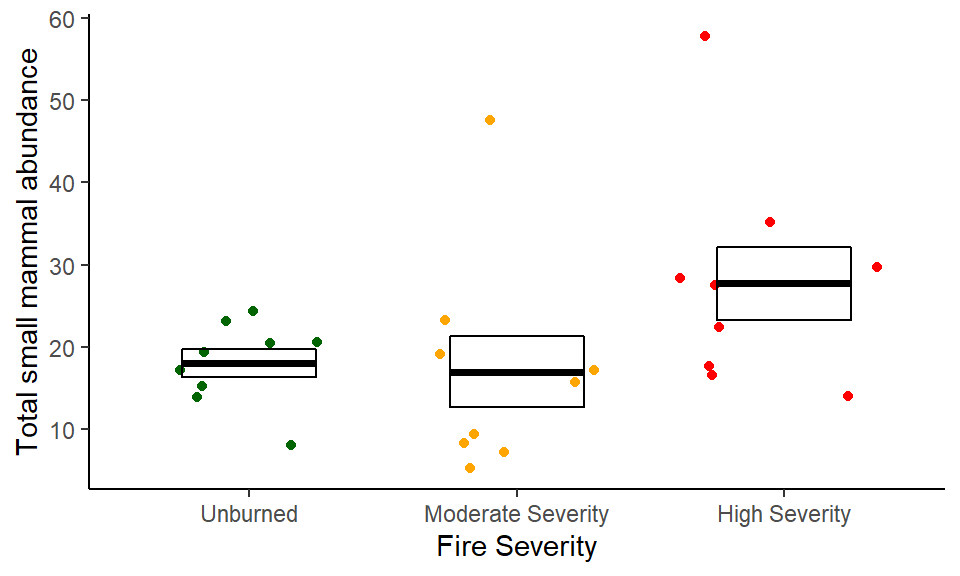

Jitter plot points represent total small mammal abundance at each site; horizontal bars represent mean and standard error for each fire severity category. Abundance was standardized by trapping effort.

Two of these sites look like outliers:

- HICORN had a ridiculous number of PEMA
- MIXMOR had a lot of PEMA, OTBE, and SOTR

### Biomass by severity

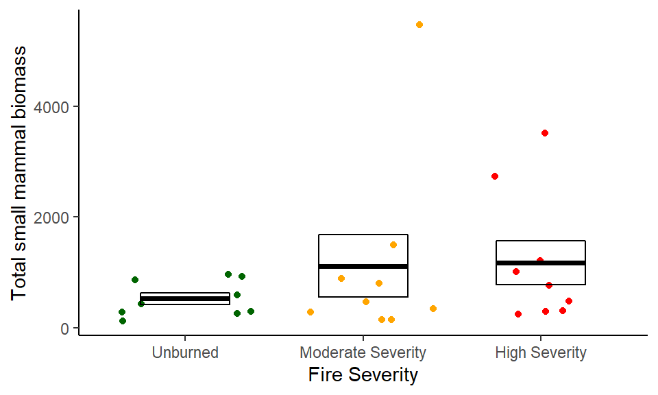

### Proportional abundance by site

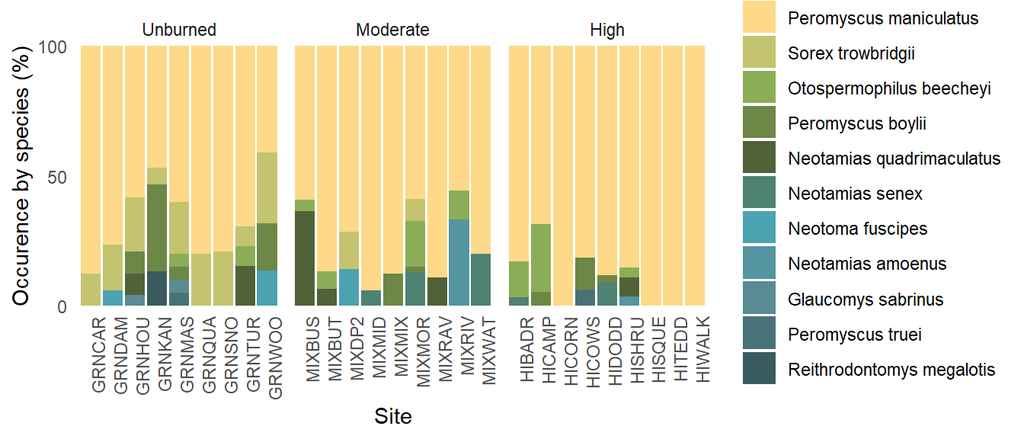

### Proportional abundance by species

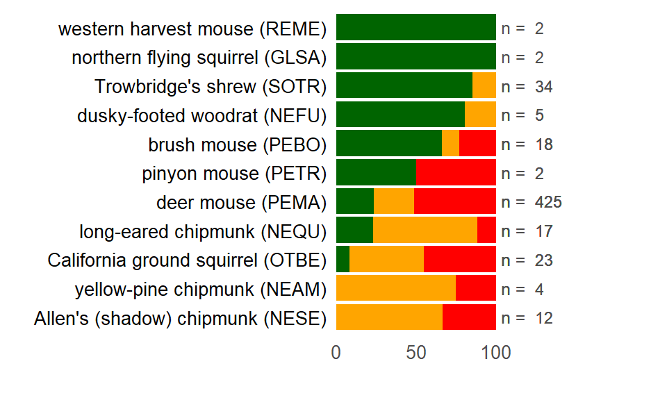

- Habitat preferences for the 11 species of mammals, standardized by trapping effort.

## Abundance by species

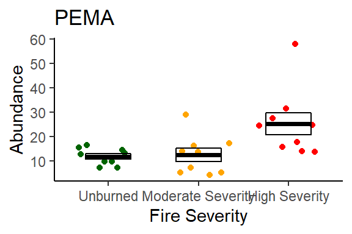

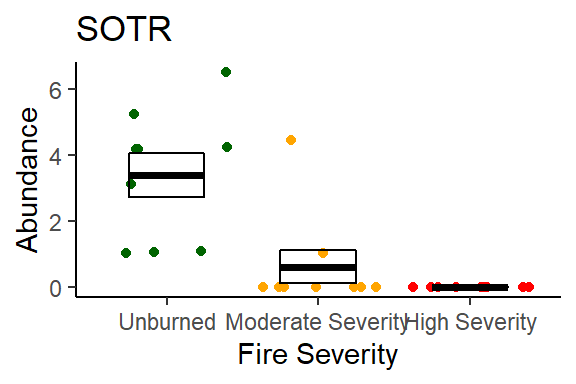

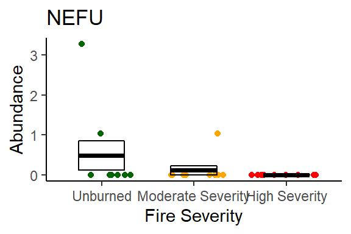

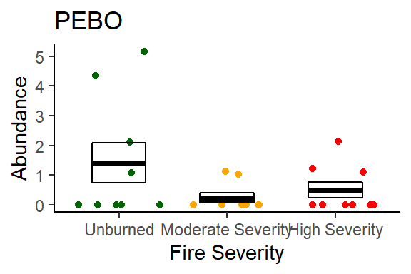

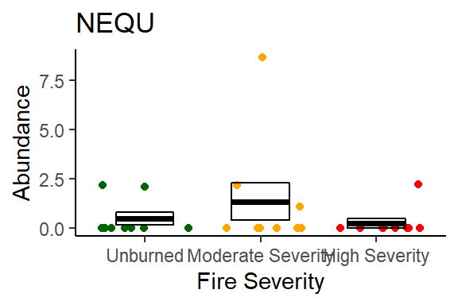

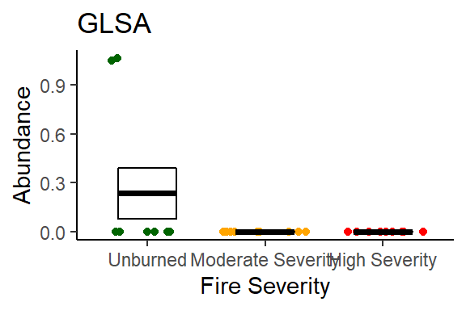

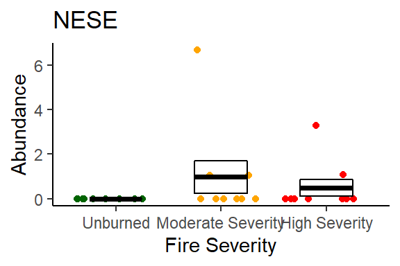

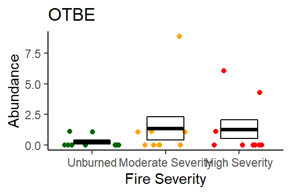

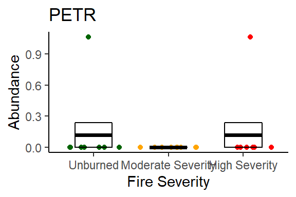

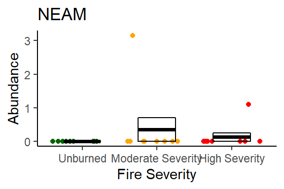

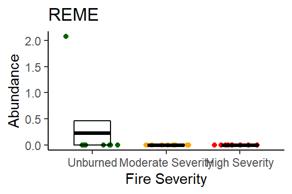

Jitter plot points represent total small mammal abundance at each site; horizontal bars represent mean and standard error for each fire severity category. Abundance was standardized by trapping effort for each species individually (i.e. non-target species were counted as half of a trap night, similar to treatment of sprung traps)

### Deer mouse (PEMA)

```
## # A tibble: 3 x 14
##   severity variable       n   min   max median    q1    q3   iqr   mad  mean    sd    se    ci
##   <fct>    <chr>      <dbl> <dbl> <dbl>  <dbl> <dbl> <dbl> <dbl> <dbl> <dbl> <dbl> <dbl> <dbl>
## 1 unb      n_adj_pema     9  7.04  16.4   12.5  9.70  14.4  4.71  4.19  11.7  3.47  1.16  2.67
## 2 mod      n_adj_pema     9  4.20  28.9   13.6  5.23  16.2 10.9   9.52  12.4  7.99  2.66  6.14
## 3 high     n_adj_pema     9 13.5   57.9   24.3 15.5   27.5 11.9  10.3   25.2 13.8   4.60 10.6
```

```
## # A tibble: 1 x 5
##   severity site   n_adj_pema is.outlier is.extreme
##   <fct>    <chr>       <dbl> <lgl>      <lgl>
## 1 high     HICORN       57.9 TRUE       FALSE
```

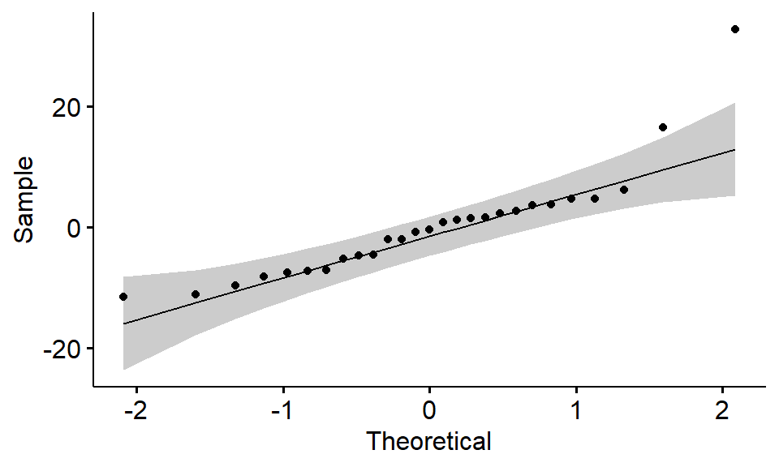

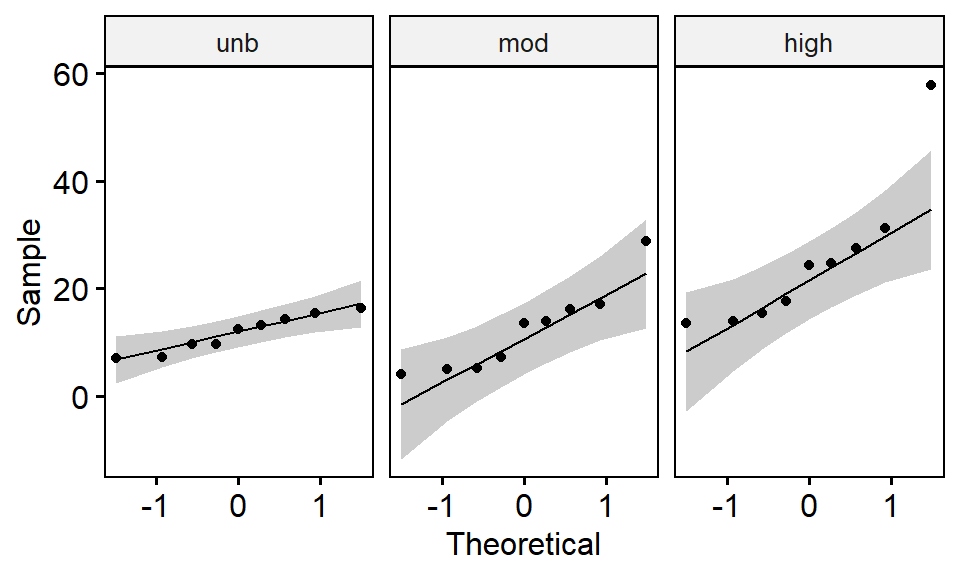

```
## # A tibble: 1 x 3
##   variable      statistic  p.value
##   <chr>             <dbl>    <dbl>
## 1 residuals(lm)     0.835 0.000598
```

```
## # A tibble: 3 x 4
##   severity variable   statistic      p
##   <fct>    <chr>          <dbl>  <dbl>
## 1 unb      n_adj_pema     0.927 0.456
## 2 mod      n_adj_pema     0.882 0.164
## 3 high     n_adj_pema     0.793 0.0170
```

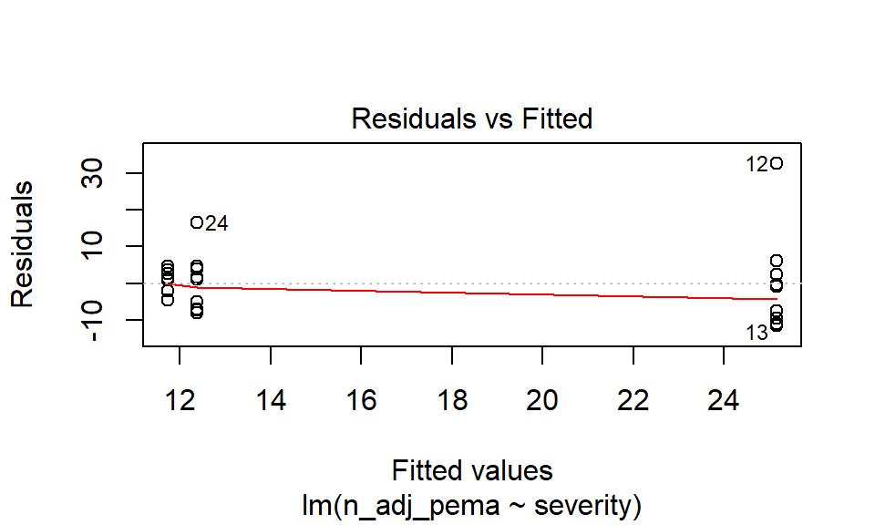

```
## # A tibble: 1 x 4
##     df1   df2 statistic     p
##   <int> <int>     <dbl> <dbl>
## 1     2    24      1.96 0.163
```

```
## # A tibble: 1 x 6
##   .y.            n statistic    df       p method
## * <chr>      <int>     <dbl> <int>   <dbl> <chr>
## 1 n_adj_pema    27      9.25     2 0.00982 Kruskal-Wallis
```

```
## # A tibble: 1 x 5
##   .y.            n effsize method  magnitude
## * <chr>      <int>   <dbl> <chr>   <ord>
## 1 n_adj_pema    27   0.302 eta2[H] large
```

```
## # A tibble: 3 x 9
##   .y.        group1 group2    n1    n2 statistic       p  p.adj p.adj.signif
## * <chr>      <chr>  <chr>  <int> <int>     <dbl>   <dbl>  <dbl> <chr>
## 1 n_adj_pema unb    mod        9     9     0.178 0.859   0.859  ns
## 2 n_adj_pema unb    high       9     9     2.72  0.00657 0.0197 *
## 3 n_adj_pema mod    high       9     9     2.54  0.0111  0.0222 *
```

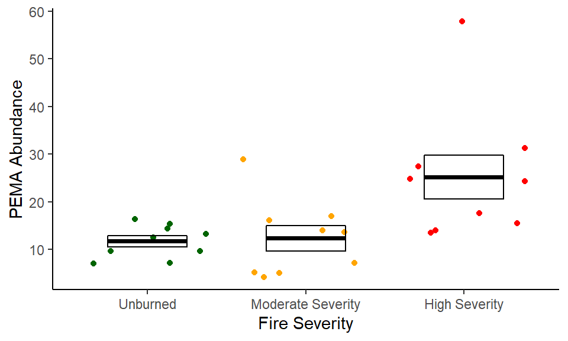

- ANOVA F=5.619, p=0.0103
- Tukey unb vs. high p=0.0158, mod vs. high p=0.0253

### Trowbridge’s shrew (SOTR)

```
## # A tibble: 3 x 14
##   severity variable       n   min   max median    q1    q3   iqr   mad  mean    sd    se    ci
##   <fct>    <chr>      <dbl> <dbl> <dbl>  <dbl> <dbl> <dbl> <dbl> <dbl> <dbl> <dbl> <dbl> <dbl>
## 1 unb      n_adj_sotr     9  1.01  6.50   4.18  1.09  4.23  3.14  1.60  3.40  1.98 0.662  1.53
## 2 mod      n_adj_sotr     9  0     4.46   0     0     0     0     0     0.61  1.48 0.495  1.14
## 3 high     n_adj_sotr     9  0     0      0     0     0     0     0     0     0    0      0
```

```
## # A tibble: 2 x 5
##   severity site   n_adj_sotr is.outlier is.extreme
##   <fct>    <chr>       <dbl> <lgl>      <lgl>
## 1 mod      MIXDP2       1.03 TRUE       TRUE
## 2 mod      MIXMOR       4.46 TRUE       TRUE
```

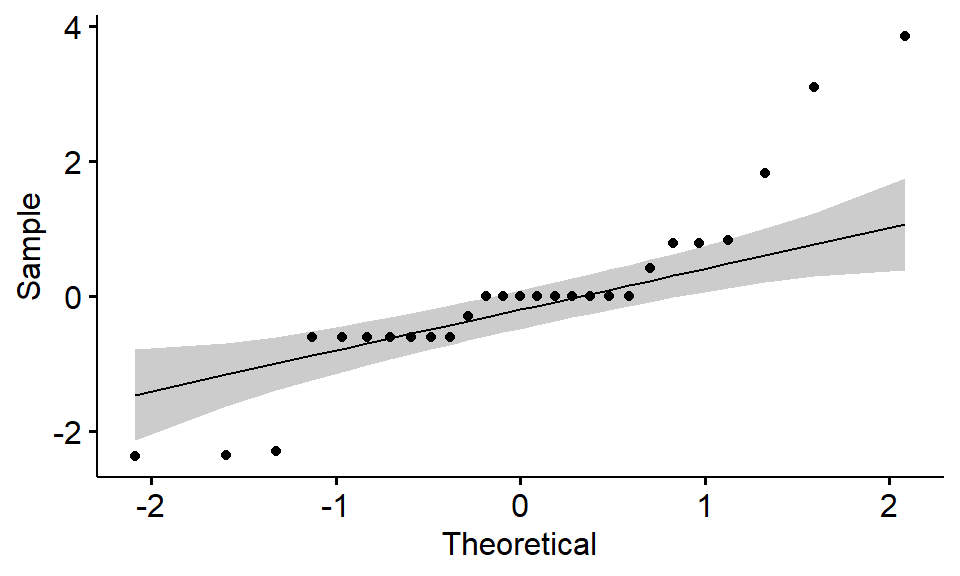

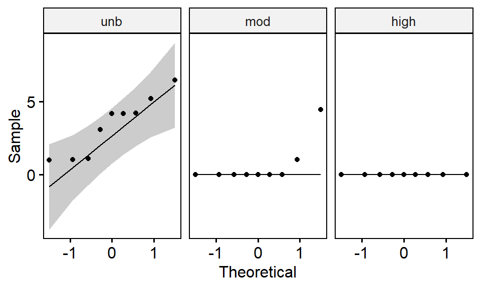

```
## # A tibble: 1 x 3
##   variable      statistic p.value
##   <chr>             <dbl>   <dbl>
## 1 residuals(lm)     0.867 0.00251
```

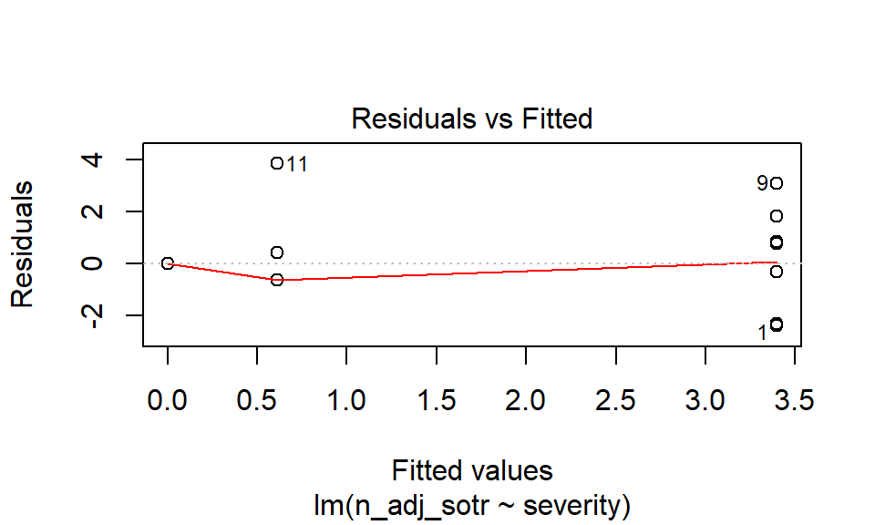

```
## # A tibble: 1 x 4
##     df1   df2 statistic      p
##   <int> <int>     <dbl>  <dbl>
## 1     2    24      3.93 0.0333
```

```
## Kruskal-Wallis chi-squared
##                  0.6867767
```

```
##   Kruskal-Wallis rank sum test
##
## data: x and group
## Kruskal-Wallis chi-squared = 18.543, df = 2, p-value = 0
##
##
##                            Comparison of x by group
##                                 (No adjustment)
## Col Mean-|
## Row Mean |       high        mod
## ---------+----------------------
##      mod |  -0.867334
##          |     0.1929
##      unb |  -4.086477  -3.219143
##          |    0.0000*    0.0006*
##
## alpha = 0.05
## Reject Ho if p <= alpha/2
```

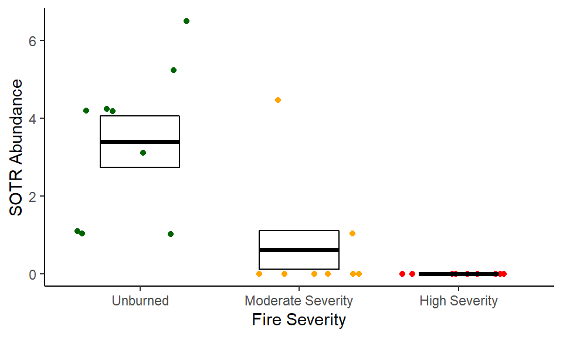

## Population size by Schnabel’s estimate

**Population size, as calculated from the Schnabel estimate:**

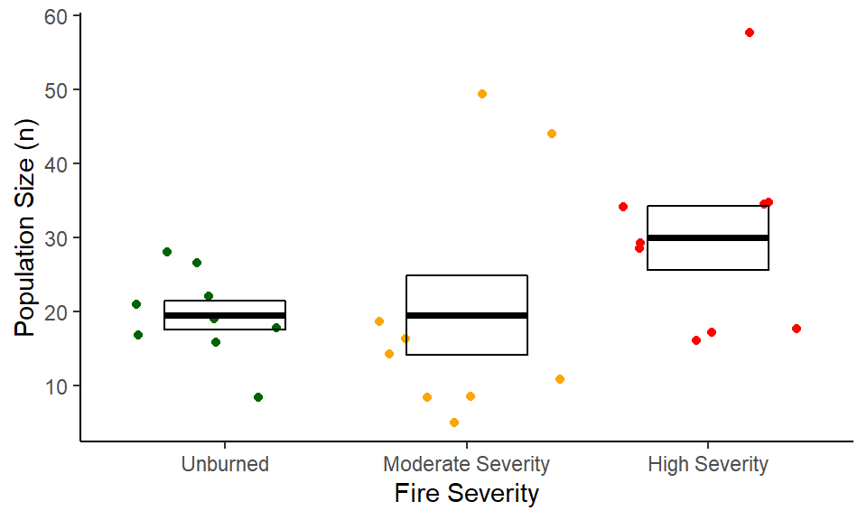

**Capture rate at the three treatments:**

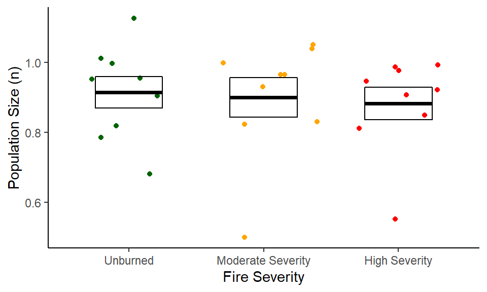

- Capture rate calculated as the number of unique individuals captured divided by the Schnabel estimate of population size.
- All but three sites had a capture rate >75%.